# S&P 500

Chris Jedras & Jim Vallandingham

July 13, 2014

## Overview

Here is the adjusted return for the S&P 500 since 1950.

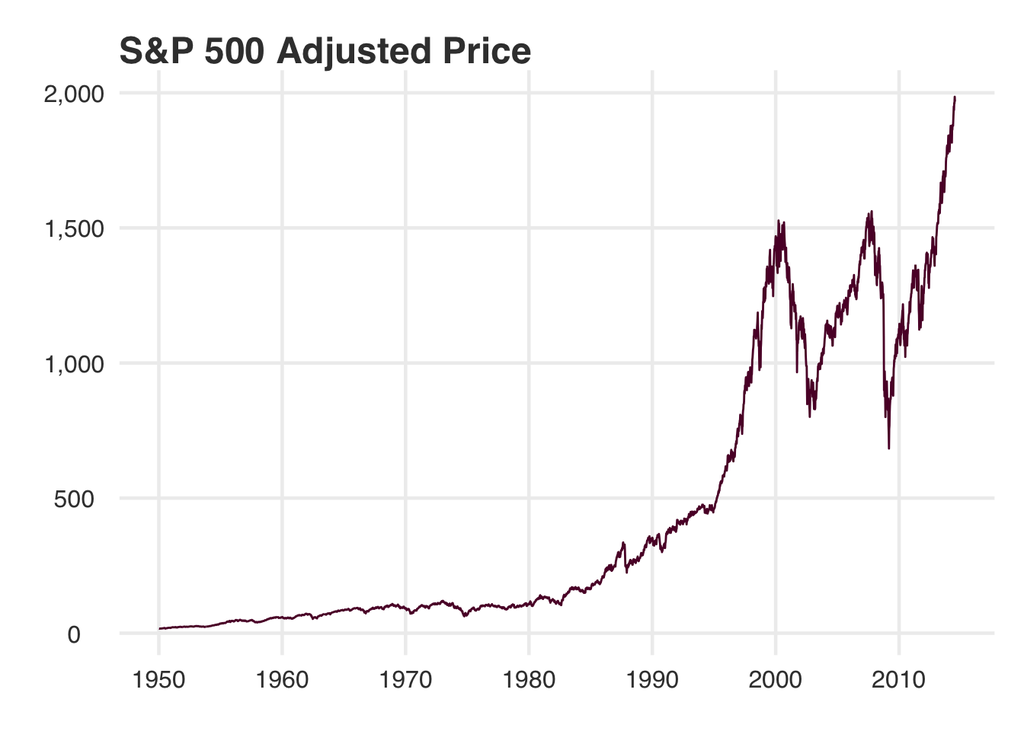

Ok. That is for the whole time period, weekly. Let’s look at a subset. Here is the last 12 months:

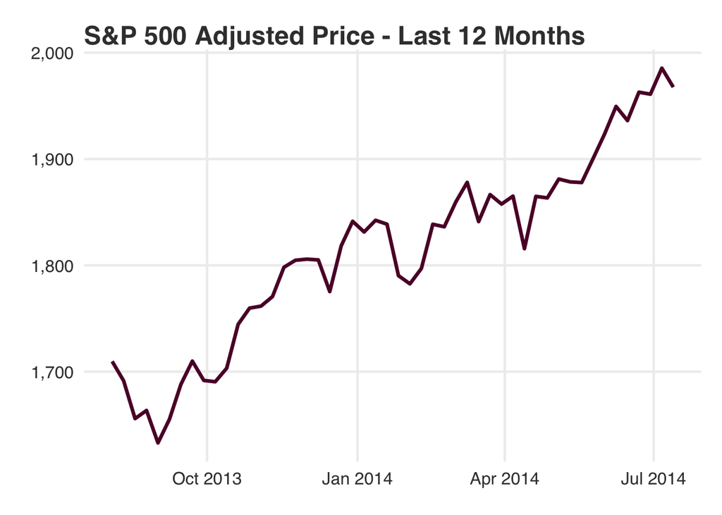

Record Highs!

## Log Returns

Here we are taking the lagged log difference between a week and the week prior. The equation looks like:

```r
prices2returns <- function(x) 100*diff(log(x))
```

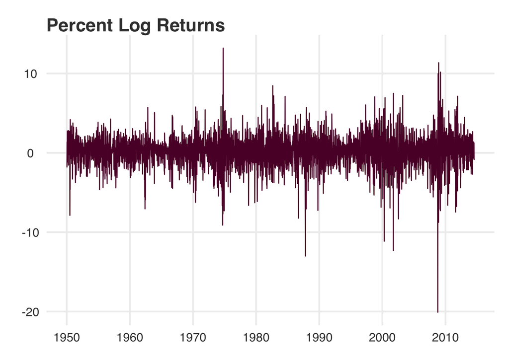

## Performance Analytics Package

Now, let’s try our hand at calculating some metrics using the [Performance Analytics Package](http://cran.r-project.org/web/packages/PerformanceAnalytics/PerformanceAnalytics.pdf). First, weekly returns:

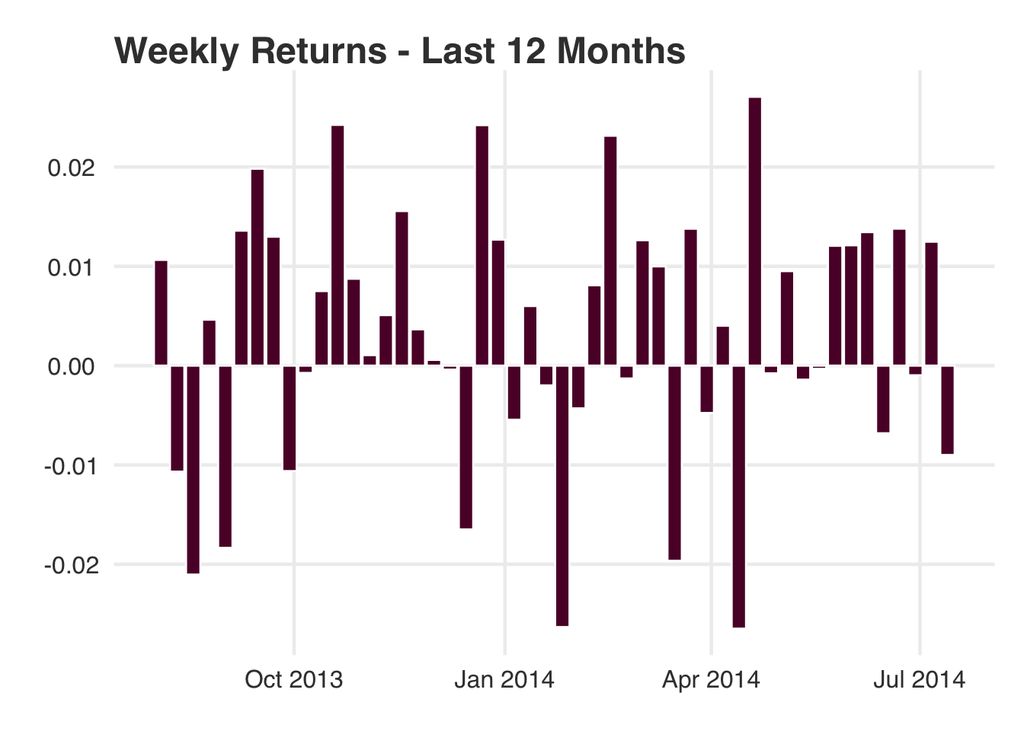

Verify the cumulative return for the last 12 months:

```
##                    Open   High    Low  Close   Volume Adjusted Close
## Cumulative Return 0.165 0.1636 0.1692 0.1631 -0.02828         0.1631
```

Graph this value over time:

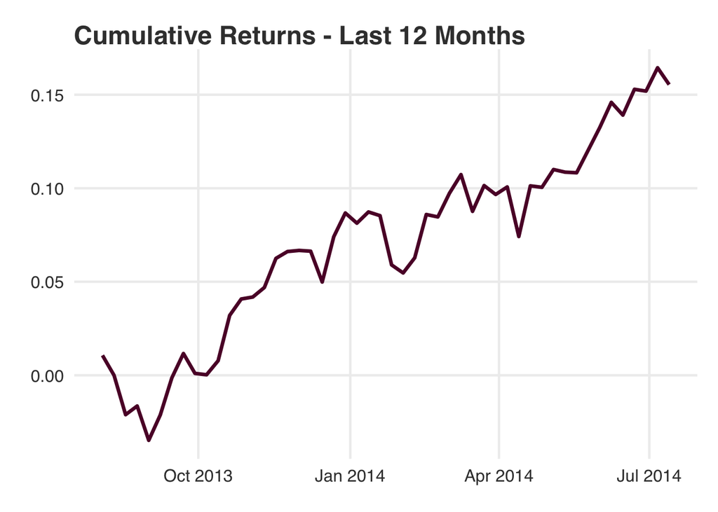

## Drawdowns

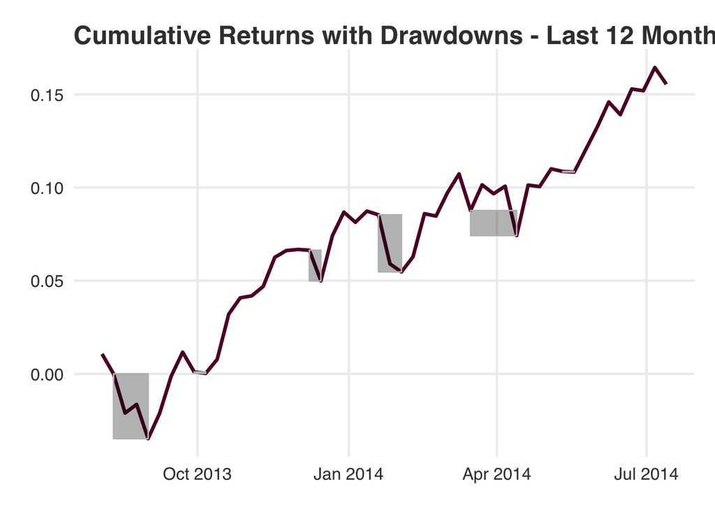

Not sure the display is correct yet. Will keep working on it. There are more drawdowns then visible - but they only last one week, so my current display excludes them. I believe this is a mistake.

## Comparing Stocks

Let’s add a few more stock picks: Apple (AAPL) and IBM (IBM).

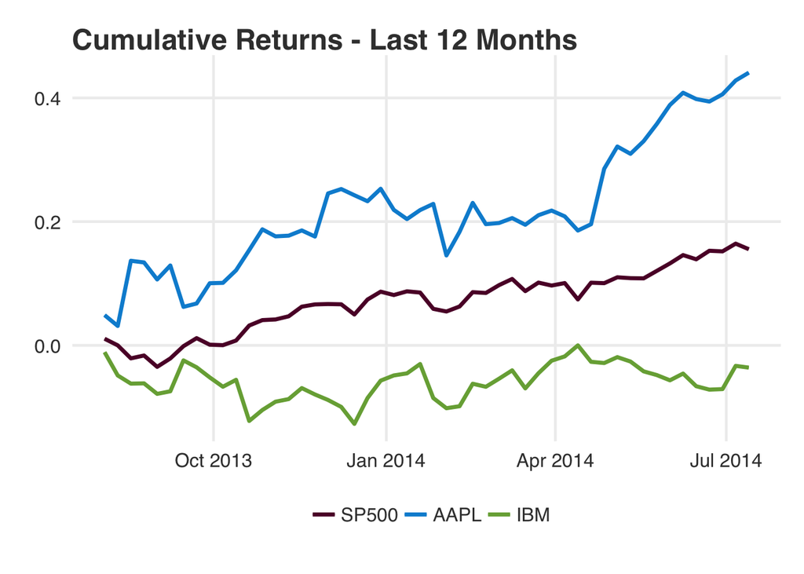

A histogram of returns provides a sense of the distributions of returns for each asset. We can see the deviation from the more normal distribution of the S&P 500 of the two individual stocks.

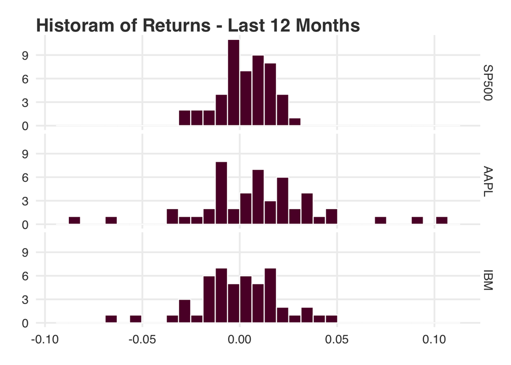

Kurtosis and Skew can also be measured for these assets.

```
##                   SP500  AAPL    IBM
## Excess Kurtosis -0.2239 1.802 0.8272
```

```
##            SP500   AAPL     IBM
## Skewness -0.4445 0.1984 -0.3397
```